# Desert Bird Habitat Use

Malory Owen & Christopher Lortie

2019

# Introduction

Bird community structure in an area changes with the seasons, as birds migrate in Spring to their Summer breeding grounds. During their migration, some will encounter habitats unlike their breeding grounds, allowing for unique interactions between mesohabitat structures. However, some birds are Summer residents of an area, meaning they are traveling *to* a particular area for their breeding season. Lastly, there are also birds that are year long residents, meaning they do not migrate to or from a location. We are investigating the relationship between different migratory classes of birds and the way they interact with available desert mesohabitats.

Our explanatory variables, which are all metrics for diversity, include:

1. Taxanomic diversity
- Species
- Family
- Order
- Shannon Weaver Index
2. Functional diversity
- Trophic guild
- Migratory class

Our response variables, behavior and mesohabitat, include:

1. Behavior
- Fine behavior
- Broad behavior
2. Mesohabitat
- Fine mesohabitat
- Two level mesohabitat
- Three level mesohabitat
- Five level mesohabitat

Here, we are examining bird habitat use as it relates to different metrics for diversity (acutal and functional) in a low-anthropogenic-impact, well preserved desert space.

# Data

## Raw data

```
##   unique.bird bird.id     date season walk start.time end.time      lat
## 1     3flower       3 5/1/2019 flower    1      10:27    12:27 34.78404
## 2     4flower       4 5/1/2019 flower    1      10:27    12:27 34.78290
## 3     5flower       5 5/1/2019 flower    1      10:27    12:27 34.78230
## 4     6flower       6 5/1/2019 flower    1      10:27    12:27 34.78244
## 5     7flower       7 5/1/2019 flower    1      10:27    12:27 34.78238
## 6     8flower       8 5/1/2019 flower    1      10:27    12:27 34.78224
##         lon         order          family       species migratory.class
## 1 -115.6603 Passeriformes Ptiliogonatidae   Phainopepla             tbd
## 2 -115.6624 Columbiformes      Columbidae Mourning Dove             tbd
## 3 -115.6625 Passeriformes Ptiliogonatidae   Phainopepla             tbd
## 4 -115.6625 Passeriformes Ptiliogonatidae   Phainopepla             tbd
## 5 -115.6626 Passeriformes    Fringillidae   House Finch             tbd
## 6 -115.6621       Unknown         Unknown       Unknown             tbd
##   trophic.guild              behavior                 broad.behavior
```

[output cut: 27 more lines]

```
##  [1] Phainopepla
##  [2] Mourning Dove
##  [3] House Finch
##  [4] Unknown
##  [5] Violet.green Swallow
##  [6] Ash.throated Flycatcher
##  [7] Northern Mockingbird
##  [8] Unknown Hummingbird
##  [9] Black.throated Sparrow
## [10] Cactus Wren
## [11] Crissal Thrasher
## [12] Black.headed Grosbeak
## [13] Blue.gray Gnatcatcher
## [14] Pacific.slope Flycatcher
## [15] Loggerhead Shrike
```

[output cut: 29 more lines]

```
##  [1] Ptiliogonatidae Columbidae      Fringillidae    Unknown
##  [5] Hirundinidae    Tyrannidae      Mimidae         Trochilidae
##  [9] Passerellidae   Troglodytidae   Cardinalidae    Polioptilidae
## [13] Laniidae        Icteridae       Remezidae       Parulidae
## [17] Picidae         Apodidae        Odontiphoridae  Vireonidae
## [21] Cuculidae
## 21 Levels: Apodidae Cardinalidae Columbidae Cuculidae ... Vireonidae
```

```
## [1] Passeriformes Columbiformes Unknown       Apodiformes   Piciformes
## [6] Galliformes   Cuculiformes
## 7 Levels: Apodiformes Columbiformes Cuculiformes Galliformes ... Unknown
```

```
##  [1] Flying                  Standing on ground      Flying between plants
##  [4] Singing                 Standing on plant       Sparring
##  [7] Foraging                Calling                 Flying on plant
## [10] Eating fruit            Copulating              Preening
## [13] Carrying nest materials Walking                 Distraction display
## 15 Levels: Calling Carrying nest materials Copulating ... Walking
```

```
##  [1] air               rock              cactus canopy     shrub
##  [5] cactus understory gravel            grass             annuals
##  [9] wash              yucca             cactus
## 11 Levels: air annuals cactus cactus canopy cactus understory grass ... yucca
```

## Explanatory Variables

We need to create a dataset with abundances of levels in each explantory factor per walk.

## Aggregations

### Difference in community between seasons

### Multiple metrics of community structure

I’d like to see the different metrics for community structure that ecologists use, so I need to create a dataset of all of these values, with “walk” as the replication level

# Viz

## Maps

[figure not shown]

```r
#map of all bird sitings
deep.sunset <- get_map(location = c(lon = -115.663, lat = 34.7805), zoom = 17, color="bw")
site.wide.map <- ggmap(deep.sunset)
site.wide.map <- site.wide.map +
  geom_point(data=site, aes(x=lon, y=lat, colour = order, group = order), alpha = 3/10, size =4) +
  labs(title = "Site Wide Species Observations", x = "longitude", y = "latitude", color = "Order")
site.wide.map
```

## Histograms

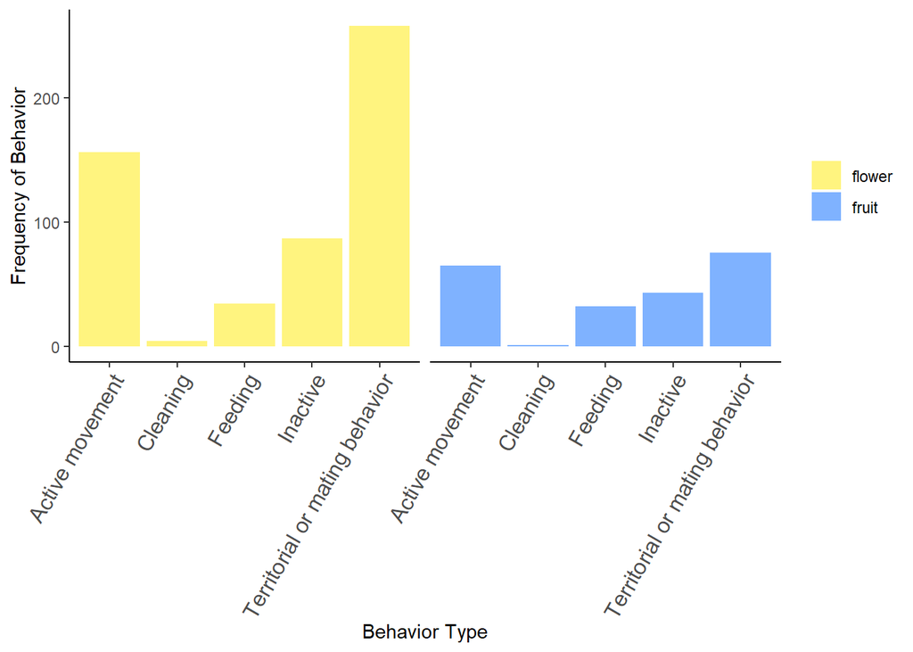

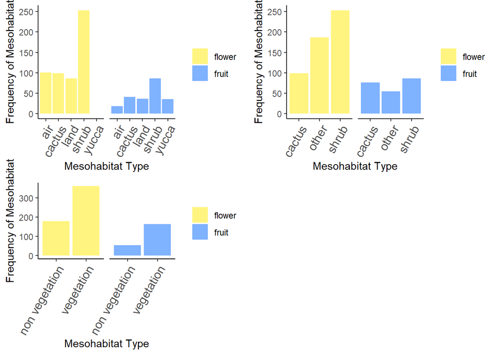

[figure not shown]

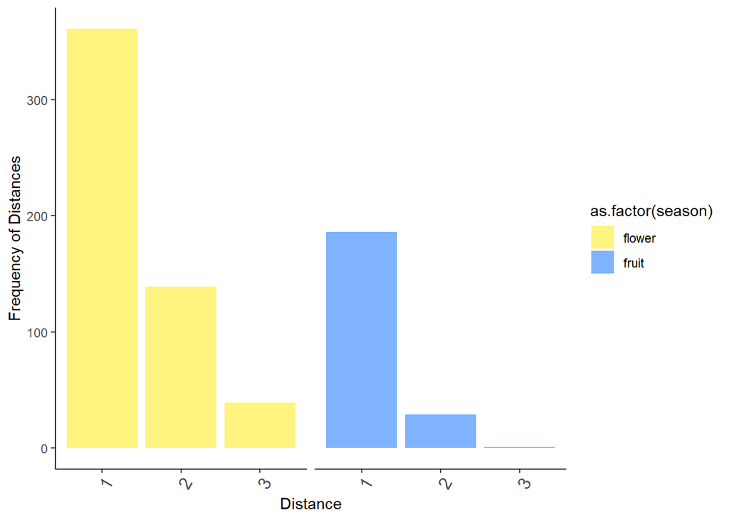

## Community Structure Metrics

Here we will visualize some standard metrics of community structure. These metrics include Shannon Weaver Indices, Simpson’s Diversity Indices, Abudances, Richness, Evenness, and Turnover.

### Distributions

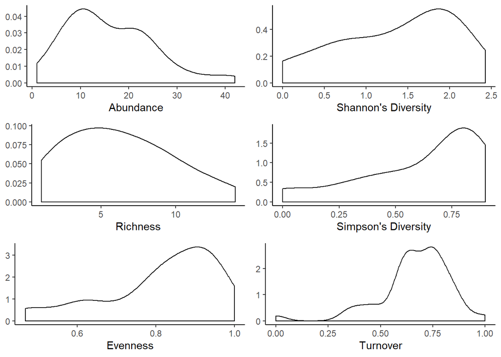

### Boxplots of Community Structure Metrics between Seasons

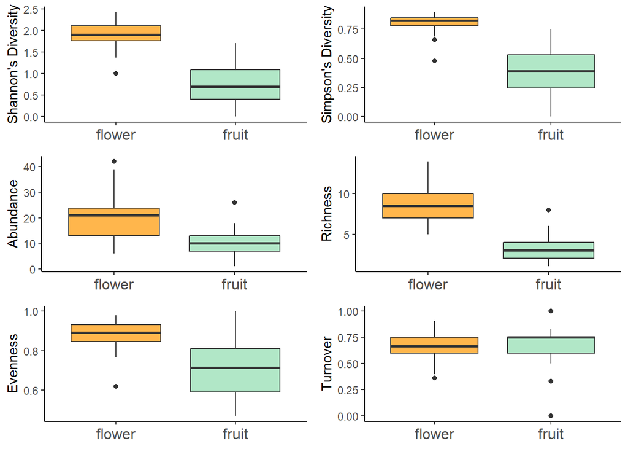